# Problem Set 4

Patrick Altmeyer

10 March, 2021

# Problem 13

# Problem 14

# Problem 15

The function below generates data with the desired distribution:

```r
sim_data <- function(n = 100, d = 5, a = 0.5) {
    y <- 2 * (rbinom(n, 1, 0.5) - 0.5)  # generate binary outcome
    X <- matrix(rnorm(n * d), n) + matrix(kronecker(y,
        matrix(c(a, rep(0, d - 1)))), n, byrow = T)
    return(list(X = X, y = y))
}
```

Figure 1 provides a quick sanity check: it plots the class-conditional densities of $\mathbf{X}$ where $d=5$, $n=10^{5}$ and $a=0.5$. The data looks normally distributed and the vectors of class conditional empirical means rounded to the nearest decimal are

$$\begin{aligned}
&& \mathbf{\bar{X}}_{\mathbf{y}=1} = \begin{bmatrix} 0.5 \\ 0 \\ 0 \\ 0 \\ 0 \\ \end{bmatrix} &, \mathbf{\bar{X}}_{\mathbf{y}=-1} = \begin{bmatrix} -0.5 \\ 0 \\ 0 \\ 0 \\ 0 \\ \end{bmatrix} \\
\end{aligned}$$

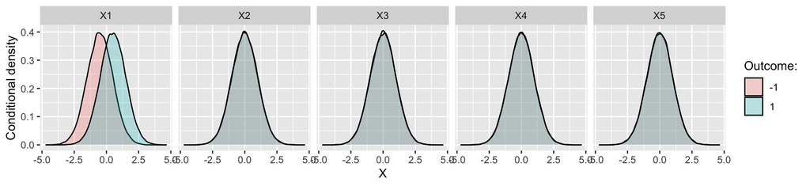

Figure 1: Class-conditional empirical densities.

To implement linear classification through stochastic gradient descent using different surrogate loss functions $\phi$, we firstly need to derive analytical solutions for the corresponding gradients. For the exponential loss $\phi(-\mathbf{w}^T\mathbf{x}_i y_i)=\exp(-\mathbf{w}^T\mathbf{x}_i y_i)$ we simply have:

$$\begin{equation}
\begin{aligned}
&& \nabla \phi(-\mathbf{w}^T\mathbf{x}_i y_i)&=-\mathbf{x}_i y_i \exp(-\mathbf{w}^T\mathbf{x}_i y_i)\\
\end{aligned}
\tag{1}
\end{equation}$$

For the Hinge loss $\phi(-\mathbf{w}^T\mathbf{x}_i y_i)=(1-\mathbf{w}^T\mathbf{x}_i y_i)_+$ we have:

$$\begin{equation}
\begin{aligned}
&& \nabla \phi(-\mathbf{w}^T\mathbf{x}_i y_i)&= \begin{cases} -\mathbf{x}_i y_i & \text{if} \ \ \ \mathbf{w}^T\mathbf{x}_i y_i \le 1\\ 0 & \text{otherwise} \end{cases} \\
\end{aligned}
\tag{2}
\end{equation}$$
Finally, for log-loss $\phi(-\mathbf{w}^T\mathbf{x}_i y_i)=\log_2(1+\exp(-\mathbf{w}^T\mathbf{x}_i y_i))$ we have:

$$\begin{equation}
\begin{aligned}
&& \nabla \phi(-\mathbf{w}^T\mathbf{x}_i y_i)&=-\mathbf{x}_i y_i \frac{\exp(-\mathbf{w}^T\mathbf{x}_i y_i)}{\left(\exp(-\mathbf{w}^T\mathbf{x}_i y_i)+1\right)\log(2)} \\
\end{aligned}
\tag{3}
\end{equation}$$

The algorithm can then be implemented as below. The main function `linear_classifier` runs the stochastic gradient descent for a given choice of the surrogate loss function. The methods that follows further below simply define what the class `linear_classifier` prints and how we can predict from it, once it is fitted.

```r
# Stochastic gradient descent: ----
linear_classifier <- function(X, y, eta = 0.001, n_iter = 1000,
    w_init = NULL, loss = "exp", save_steps = FALSE) {
    # Initialization:
    n <- nrow(X)
    d <- ncol(X)
    if (is.null(w_init)) {
        w <- matrix(rep(0, d))
    } else {
        w <- matrix(w_init)
    }
    if (save_steps) {
        steps <- data.table(iter = 0, w = c(w), d = 1:d)
    } else {
        steps <- NA
    }
    w_avg <- 1/n_iter * w
    iter <- 1
    # Surrogate loss:
    if (loss == "exp") {
        l <- function(X, y, w) {
            exp(-1 * crossprod(X, w) %*% y)
        }
        grad <- function(X, y, w) {
            (-1) * X %*% y %*% exp((-1) * crossprod(X,
                w) %*% y)
        }
    } else if (loss == "hinge") {
        l <- function(X, y, w) {
            x <- (-1) * crossprod(X, w) * y
            pmax(0, 1 + x)
        }
        grad <- function(X, y, w) {
            x <- (-1) * crossprod(X, w) * y
            X %*% ifelse(crossprod(X, w) * y <= 1,
                -y, 0)
        }
    } else if (loss == "log") {
        l <- function(X, y, w) {
            x <- crossprod(X, w) * y
            log2(1 + exp(x))
        }
        grad <- function(X, y, w) {
            x <- (-1) * crossprod(X, w) * y
            (-1) * X %*% y %*% (exp(x)/(exp(x) * log(2) +
                log(2)))
        }
    }
    # Descent:
    while (iter <= n_iter) {
        t <- sample(1:n, 1)
        X_t <- matrix(X[t, ])
        y_t <- matrix(y[t])
        v_t <- grad(X_t, y_t, w)
        # Update:
        w <- w - eta * v_t
        if (!is.na(w) & is.finite(w)) {
            w_avg <- w_avg + 1/n_iter * w
        }
        if (save_steps) {
            steps <- rbind(steps, data.table(iter = iter,
                w = c(w), d = 1:d))
        }
        iter <- iter + 1
    }
    output <- list(X = X, y = matrix(y), coefficients = w_avg,
        eta = eta, n_iter = n_iter, loss = loss, steps = steps)
    class(output) <- "linear_classifier"
    return(output)
}

# Methods: ----
print.linear_classifier <- function(linear_classifier) {
    print("Coefficients:")
    print(linear_classifier$coefficients)
}
print <- function(linear_classifier) {
    UseMethod("print")
}

predict.linear_classifier <- function(linear_classifier,
    newdata = NULL, discrete = TRUE) {
    if (!is.null(newdata)) {
        fitted <- newdata %*% linear_classifier$coefficients
    } else {
        fitted <- linear_classifier$X %*% linear_classifier$coefficients
    }
    if (discrete) {
        fitted <- sign(fitted)
    }
    return(fitted)
}
predict <- function(linear_classifier, newdata = NULL,
    discrete = TRUE) {
    UseMethod("predict")
}
```

The algorithm is run for the three different loss functions and many different values of $n$, $d$, $\eta$, $a$ and $T$ (the number of iterations). Figures (2), (3) and (4) show the resulting train and test error frequencies conditional on the different parameter choices. A first general observation is that the Bayes classifier outperforms the linear classifier, independent of the choice of $\phi$, which was to expect. The choice of the surrogate loss function does not appear to have a major impact on accuracy.

Figure (2) shows error frequencies by sample size and dimension for different classifiers averaged across all other dimensions. It demonstrates that the test error initially decreases as a function of $n$ and increases as a function of $d$, again as one would expect. What is somewhat curious is the fact the the opposite relationship appears to hold for the training error. It appears that for small choices of $n$, higher values of $d$ achieve higher in-sample accuracy. What this illustrates is overfitting: within the framework of the bias-variance trade-off, $d>>n$ in these cases leads to very small bias, but high variance (hence the poor out-of-sample performance in those cases).

Figure (3) shows error frequencies by parameter $a$ and number of iterations $T$ for different classifiers (again averaged across all other dimensions). As one would expect, the accuracy increases across the board as the number of iterations increases. With respect to $a$, the increase in accuracy is also intuitive, since for greater $a$ the likelihood of being able to perfectly separate the labels conditional on $\mathbf{X}$ increases. In fact, for $a=5$ the linear classifier commits no errors. The Bayes classifier is of course independent of the number of iterations (since it does not iterate), but depends on $a$ in the same way as the linear classifier.

Finally, Figure (4) shows error frequencies by learning rate and number of iterations for different classifiers (once again averaged across all other dimensions). For the given choices of $\eta$ and the number of iterations we see no relationship between the choice of $\eta$ and the resulting error frequency. But Figure (4) fails to illustrate the rate of convergence, which is what the learning rate $\eta$ primarily affects. Below we will see how exactly $\eta$ comes into play.

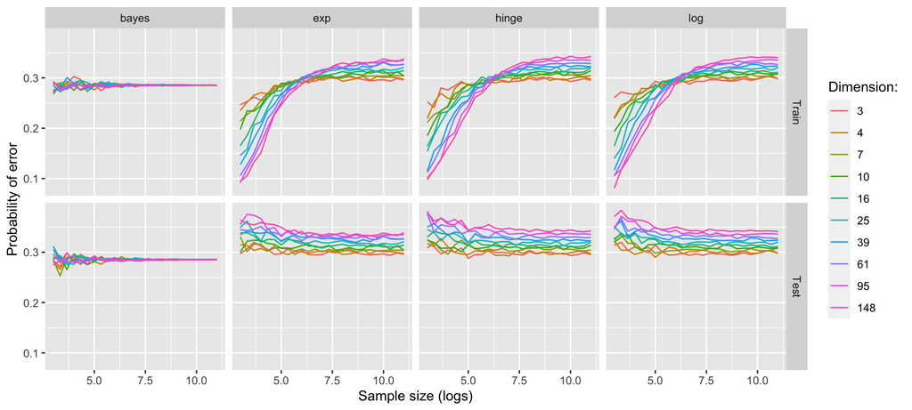

Figure 2: Train and test error frequencies by sample size and dimension for different classifiers (averaged across all other dimensions).

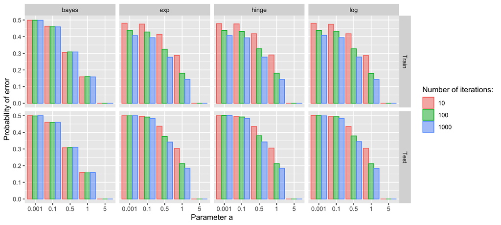

Figure 3: Train and test error frequencies by parameter a and number of iterations for different classifiers (averaged across all other dimensions).

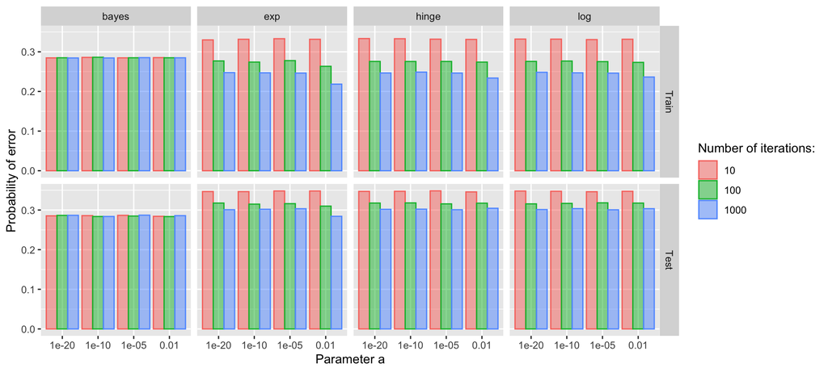

Figure 4: Train and test error frequencies by learning rate and number of iterations for different classifiers (averaged across all other dimensions).

To illustrate how the the algorithm depends on the learning rate $\eta$, let us consider a simple example where $x_i\in\mathbb{R}$ is $1$-dimensional and $\mathbf{y}$ is perfectly linearly separable given $\mathbf{x}$. In this case, the problem becomes trivial for binary $y$, so to make things a little more interesting at this point, let us add some additional noise for a moment. In particular, let $y_i \in \{-1+\varepsilon_i,1+\varepsilon_i \}$ where $\varepsilon_i \sim \mathcal{N}(0,0.5^2)$. In this context linear separability can still be achieved by choosing a high value for $a$, say $a = 5$. Now we will run the algorithm for different values of $\eta$, namely:

$$\begin{aligned}
&& \eta&=\begin{bmatrix} 0.1 \\ 0.05 \\ 0.01 \\ \end{bmatrix} \\
\end{aligned}$$

Figure (5) demonstrates that the algorithm takes longer to converge for the more conservative choice of $\eta=0.01$, as one would expect. In fact, for this choice of $\eta$ the linear classifier does not manage to perfectly separate the two clusters after $n=100$ iterations.

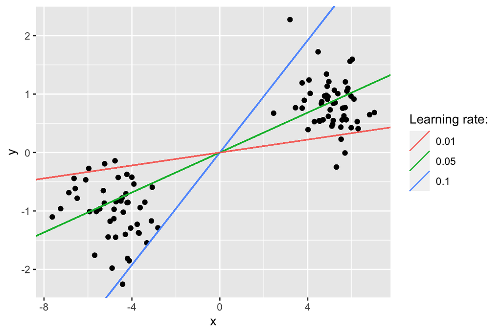

Figure 5: The effect of the learning rate on time to convergence.